# Making Choices about the EVS data

Anonymized for peer review

9/22/2020

# Countries and Observations: Matrix Desing VS Integrated data

Observations are devided in

```r
lapply(list(int.dt = int.dt$mm_select_sample,
            mad.dt = mad.dt$mm_select_sample), table)
```

```
## $int.dt
##
##     1     2     3     4
## 47195  3793   437  3851
##
## $mad.dt
##
##    2    3    4    5    6    7
## 1316  437 3851 1635 3237  122
```

And you can see here what those values mean:

```r
val_labels(int.dt$mm_select_sample)
```

```
##                                        interviewer-administered (CAPI PAPI CATI)
##                                                                                1
## self-administered full-length questionnaire: original question order (CAWI Mail)
##                                                                                2
## self-administered full-length questionnaire: modified question order (CAWI Mail)
##                                                                                3
##                             self-administered matrix: with follow-up (CAWI Mail)
##                                                                                4
##                     self-administered matrix: follow-up non response (CAWI Mail)
##                                                                                5
##                     self-administered matrix: first survey only (CAWI Mail - DE)
##                                                                                6
##                                          break-off (less than 50% valid answers)
##                                                                                7
```

If you consider the 6 EU founding countries (Belgium, France, Germany, Italy, Luxembourg, Netherlands), this is how observations are distributed among the two datasets:

```r
countries  <- c("Belgium", "France", "Germany", "Italy", "Luxembourg", "Netherlands")

tab.1 <- table(int.df$country, int.df$mm_select_sample)
print(tab.1[rownames(tab.1) %in% countries, ])
```

```
##
##                  1    2    3    4
##   France      1870    0    0    0
##   Germany     1494  676    0    0
##   Italy       2277    0    0    0
##   Netherlands  686    0    0 1718
```

```r
tab.2 <- table(mad.df$country, mad.df$mm_select_sample)
print(tab.2[rownames(tab.2) %in% countries, ])
```

```
##
##                  2    3    4    5    6    7
##   France         0    0    0    0    0    0
##   Germany      676    0    0    0 3237   49
##   Italy          0    0    0    0    0    0
##   Netherlands    0    0 1718  324    0   11
```

- Belgium and Luxembourg are not surveyed by EVS 2017.
- Netherlands has almost 2000 observations in group 4 (self-administered matrix)

In **conclusion**:

- Countries to keep: France, Germany, Italy, Netherlands
- Subsamples to keep: 1 and 4 from the integrated dataset

```r
# What to keep
subsample <- c(1, 4)
countries <- c("France", "Germany", "Italy", "Netherlands")

# Select data
int.df <- int.df %>%
  filter(mm_select_sample %in% subsample) %>%
  filter(country %in% countries)

# Check out dimensionality
dim(int.df)
```

```
## [1] 8045  464
```

# Variables to keep

## Generic variables by type:

```r
id  <- "id_cocas"
ord <- paste0("v", c(1:8, 32:39, 46:50, 53:54, 63:70, 72:84,
                     97:107, 115:168, 170:172, 176:203, 205:224,
                     240, 242, 267:274, 280,
                     c("174_LR", "175_LR", "239_r", "239a", "239b")))
dic <- paste0("v", c(9:31,40:45,51,57:61,71,85:95,
                     112,169,225,227,230,232,236,
                     248,259,260))
nom <- paste0("v", c(52, 62, 56, # religiosity
                     108:111, 113:114, 234, 244, 238,
                     264, 265, 266, "276_r"))

# I will make sure the following variables are excluded
  excl <- c("v27", # not really a variable in the
                   # countries we are investigating (98% of responses
                   # was same category)
            "v239a", "v239b",
            # Gated
            "v53", "v247", "v248", "v252_ISCED_1", "v170",
            # Religiosity related
            "v51", "v52", "v54",
            # respondend related questions to be discarded after use
            "v228b_r",
            # father related question to discard after use
            "v230", "v231b", "v231b_r",
            # mother related question to discard after use
            "v232", "v233b", "v233b_r"
            )
```

## Political tendencies

Use a vairable measuring self reported tendency to vote for parties (recoded by EVS into a continuous variable)

```r
pol <- "v175_LR"

# Frequency table
data.frame(labels = c("other missing", "not applicable", "no anwser", "dont know",
                      "left", as.character(2:9), "rigth"),
           values = sort(unique(int.df[, pol])),
           freq   = as.numeric(table( int.df[, pol] )),
           row.names = 1)
```

```
##                values freq
## other missing      -5 1717
## not applicable     -3 1576
## no anwser          -2  368
## dont know          -1  639
## left                1   64
## 2                   2  340
## 3                   3  647
## 4                   4  582
## 5                   5  581
## 6                   6  537
## 7                   7  421
## 8                   8  294
## 9                   9  216
## rigth              10   63
```

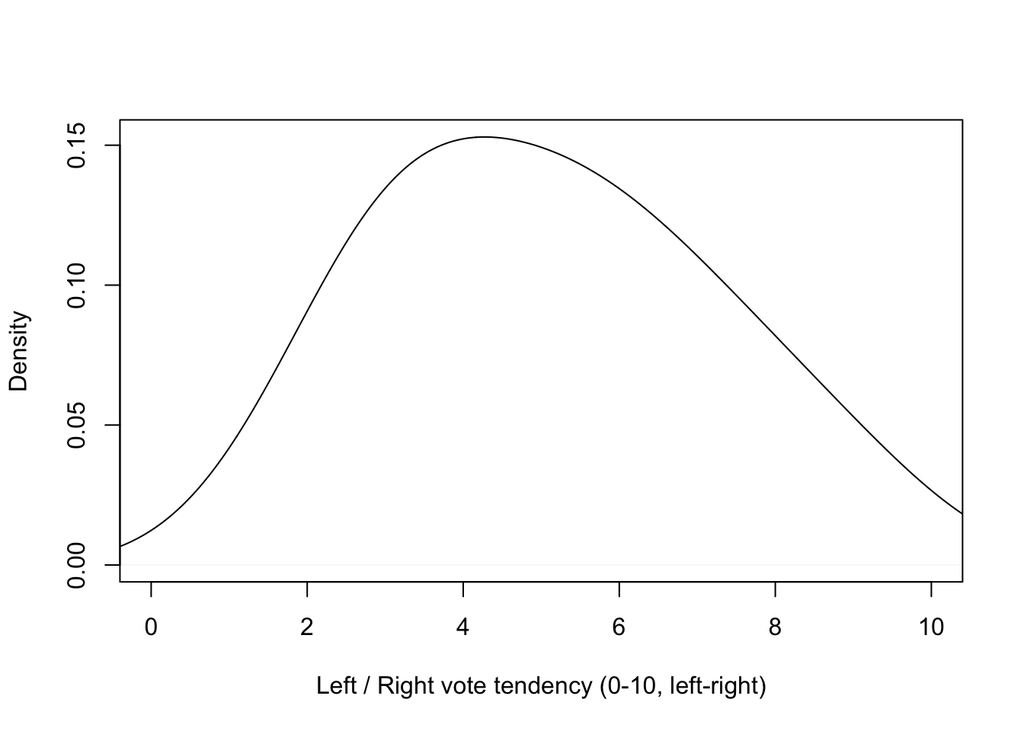

```r
# If there were cases with value 44 you could do this:
int.df[which(int.df[, pol] == 44), pol] <- NA

# Density Plot
plot(density(int.df[int.df[, pol]>0, pol],
             adjust = 3),
     main = "",
     xlim = c(0,10), xlab  = "Left / Right vote tendency (0-10, left-right)")
```

## Age

For age, I use a constructed age vairables in “number of years old” format.

```r
age <- "age"
val_labels(int.df[, age])
```

```
##  multiple answers Mail           no follow-up follow-up non response
##                    -10                     -9                     -8
##          other missing      item not included         not applicable
##                     -5                     -4                     -3
##              no answer              dont know           82 and older
##                     -2                     -1                     82
```

```r
table(int.df[, age])
```

```
##
##  -2  18  19  20  21  22  23  24  25  26  27  28  29  30  31  32  33  34  35  36
##   5  81  74 100  97  95 102  78 101 122 100 100 106  93 122 109  85 109 115 129
##  37  38  39  40  41  42  43  44  45  46  47  48  49  50  51  52  53  54  55  56
## 136 135 111 150 131 108 106 119 115 116 145 137 137 126 130 145 149 129 146 124
##  57  58  59  60  61  62  63  64  65  66  67  68  69  70  71  72  73  74  75  76
## 132 165 148 161 144 130 149 181 168 141 157 163 165 160 147  99 118 104  88  97
##  77  78  79  80  81  82
##  99  95  71  60  77 308
```

## Education

For education, I use the ISCED version and I will be treating it as continuous. I do this for the education of the respondent and their father and mother.

Values 66 need to be recoded as missings as it does not belong in any order of education.

```r
# Education
edu <- c("v243_ISCED_1", # continuous is fine
         "v262_ISCED_1",
         "v263_ISCED_1")
obsVals <- val_labels(int.df[, edu[1]]) %in% sort(unique(int.df[, edu[1]]))

data.frame(labels = names(val_labels(int.df[, edu[1]]))[obsVals],
           values = val_labels(int.df[, edu[1]])[obsVals],
           respondent = as.vector(table(int.df[, edu[1]])),
           father = as.vector(table(int.df[, edu[2]])),
           mother = as.vector(table(int.df[, edu[3]])),
           row.names = 1)
```

```
##                             values respondent father mother
## no answer                       -2         34     94     92
## dont know                       -1         22    693    580
## Less than primary                0         73    521    591
## Primary                          1        615   1869   2216
## Lower secondary                  2       1531   1788   2119
## Upper secondary                  3       3121   1813   1649
## Post-secondary non tertiary      4        185     95     80
## Short-cycle tertiary             5        482    271    145
## Bachelor or equivalent           6        678    229    188
## Master or equivalent             7       1228    605    366
## Doctoral or equivalent           8         76     67     19
```

```r
# If there were cases with 66 observed, you could:
for (j in edu) {
  int.df[which(int.df[, j] == 66), j] <- NA
}
```

## Job / Profession / SES / income

```r
# Job / SES
SES <- "v246_egp"
obsVals <- val_labels(int.df[, SES]) %in% sort(unique(int.df[, SES]))

data.frame(labels = names(val_labels(int.df[, SES]))[obsVals],
           values = val_labels(int.df[, SES])[obsVals],
           freq = as.vector(table(int.df[, SES])),
           row.names = 1)
```

```
##                          values freq
## not applicable               -3  727
## no answer                    -2  155
## don't know                   -1   46
## I :Higher Controllers         1 1282
## II :Lower Controllers         2 2013
## IIIa:Routine Nonmanual        3  661
## IIIb:Lower Sales-Service      4  769
## IVa:Selfempl with empl        5  169
## IVb:Selfempl no empl          6  274
## V :Manual Supervisors         7  329
## VI :Skilled Worker            8  476
## VIIa:Unskilled Worker         9  927
## VIIb:Farm Labor              10  104
## IVc:Selfempl Farmer          11  113
```

```r
# Income
inc <- "v261_ppp"
```

## Denomination and Religiosity

These variables need a bit of recoding: * Denomination is recorded with two variables: 1 dichotomous asking whether someone belongs to one; (2) one follow up question asking to which denomination they belong to (I want them in 1 variable). * Religiosity is recorded with higher frequency being smaller numbers (I want the opposite)

```r
den <- c("v51", # do you belong
         "v52") # which denomination do you belong to?
rel <- c("v54", "v55") # apart from ... how often services? for religiosity

# Denomination Merge
                        # If you belong to a denomination, to which?
  den_comb <- case_when(int.df[, den[1]] == 1 ~ int.df[, den[2]],
                        # You don't belong
                        int.df[, den[1]] == 2 ~ 0)

  val_labels(den_comb) <- c(val_labels(den_comb)[val_labels(den_comb) < 0],
                            "No Religion" = 0,
                            val_labels(den_comb)[val_labels(den_comb) > 0])
  int.df$den_comb <- den_comb # save it

  # Frequency Table
  obsVals <- val_labels(den_comb) %in% sort(unique(den_comb))
  data.frame(labels = names(val_labels(den_comb))[obsVals],
             values = val_labels(den_comb)[obsVals],
             freq = as.vector(table(den_comb)),
             row.names = 1)
```

```
##                                        values freq
## no answer                                  -2   26
## dont know                                  -1    3
## No Religion                                 0 3513
## Roman catholic                              1 3119
## Protestant                                  2  819
## Free church/Non-conformist/Evangelical      3   59
## Jew                                         4    7
## Muslim                                      5  238
## Hindu                                       6   26
## Buddhist                                    7   16
## Orthodox                                    8   36
## Other                                       9  106
```

```r
# Religiosity Recode
  rel_invCod <- sapply(1:length(rel), function(x) match(int.df[, rel[x]], 7:1))

  # Frequency comparison
  # Present
  data.frame(old.v54 = table(int.df[int.df[, rel[1]]>0, rel[1]],
                         dnn = c("rel")),
             new.v54 = table(rel_invCod[,1], dnn = c("rel"))[7:1])
```

```
##   old.v54.rel old.v54.Freq new.v54.rel new.v54.Freq
## 1           1          264           7          264
## 2           2          893           6          893
## 3           3          705           5          705
## 4           4         1214           4         1214
## 5           5          575           3          575
## 6           6          670           2          670
## 7           7         3662           1         3662
```

```r
  # Past
  data.frame(old.v55 = table(int.df[int.df[, rel[2]]>0, rel[2]],
                         dnn = c("rel")),
             new.v55 = table(rel_invCod[,2], dnn = c("rel"))[7:1])
```

```
##   old.v55.rel old.v55.Freq new.v55.rel new.v55.Freq
## 1           1          889           7          889
## 2           2         3156           6         3156
## 3           3          730           5          730
## 4           4          746           4          746
## 5           5          293           3          293
## 6           6          293           2          293
## 7           7         1840           1         1840
```

```r
  # Keep new recoded version
  int.df[, rel] <- rel_invCod
```

## Marital Status

Nothing special to report but it’s an important variable for the substantive model, so it deserves a bit of attention

```r
mart <- "v234"
obsVals <- val_labels(int.df[, mart]) %in% sort(unique(int.df[, mart]))

data.frame(labels = names(val_labels(int.df[, mart]))[obsVals],
           values = val_labels(int.df[, mart])[obsVals],
           freq = as.vector(table(int.df[, mart])),
           row.names = 1)
```

```
##                                                values freq
## no answer                                          -2   40
## dont know                                          -1    8
## married                                             1 3866
## registered partnership                              2  235
## widowed                                             3  705
## divorced                                            4  688
## separated                                           5  235
## never married and never registered partnership      6 2268
```

## Sex and Union Membership

Nothing special to report but it’s an important variable for the substantive model, so it deserves a bit of attention

```r
# Sex
sex <- "v225"
obsVals <- val_labels(int.df[, sex]) %in% sort(unique(int.df[, sex]))

data.frame(labels = names(val_labels(int.df[, sex]))[obsVals],
           values = val_labels(int.df[, sex])[obsVals],
           freq = as.vector(table(int.df[, sex])),
           row.names = 1)
```

```
##        values freq
## male        1 3858
## female      2 4187
```

```r
# Union Membership
um <- "v11"
obsVals <- val_labels(int.df[, um]) %in% sort(unique(int.df[, um]))

data.frame(labels = names(val_labels(int.df[, um]))[obsVals],
           values = val_labels(int.df[, um])[obsVals],
           freq = as.vector(table(int.df[, um])),
           row.names = 1)
```

```
##               values freq
## no answer         -2   35
## dont know         -1   24
## mentioned          1  744
## not mentioned      2 7242
```

## Country Variables

Here we manage the country variables. First, I need to create a map of country labels and ISO codes.

```r
ISO3116 <- data.frame(name = names(val_labels(int.df[, "v231b_r"])),
                      code = as.numeric(val_labels(int.df[, "v231b_r"])))
head(ISO3116, 20)
```

```
##                         name code
## 1      multiple answers Mail  -10
## 2               no follow-up   -9
## 3     follow-up non response   -8
## 4              other missing   -5
## 5          item not included   -4
## 6             not applicable   -3
## 7                  no answer   -2
## 8                  dont know   -1
## 9                Afghanistan    4
## 10   M49 code: South America    5
## 11                   Albania    8
## 12                Antarctica   10
## 13  M49 code: Western Africa   11
## 14                   Algeria   12
## 15 M49 code: Central America   13
## 16  M49 code: Eastern Africa   14
## 17 M49 code: Northern Africa   15
## 18            American Samoa   16
## 19   M49 code: Middle Africa   17
## 20 M49 code: Southern Africa   18
```

Then I need to create a variable that records the country of birth of the respondent, combining the variable related to the country of interview and the question of whether the respondant was born in the same country.

```r
# Interviee country of birth
re_intw  <- ISO3116$name[match(int.df[, "country_org"], ISO3116$code)] # interview
re_alter <- ISO3116$name[match(int.df[, "v228b_r"], ISO3116$code)] # birth
re_cb <- case_when(re_alter == "not applicable" ~ re_intw, # country of birth
                   re_alter != "not applicable" ~ re_alter)
# Check
set.seed(2042)
random_obs <- sample(1:length(re_cb), 10)
data.frame(interview = re_intw,
           alternative = re_alter,
           respondent = re_cb)[random_obs, ]
```

```
##         interview    alternative   respondent
## 6122  Netherlands not applicable  Netherlands
## 6847  Netherlands not applicable  Netherlands
## 7682  Netherlands not applicable  Netherlands
## 3599        Italy not applicable        Italy
## 5353        Italy not applicable        Italy
## 3003      Germany not applicable      Germany
## 4634        Italy not applicable        Italy
## 5300        Italy not applicable        Italy
## 4591        Italy not applicable        Italy
## 4381        Italy not applicable        Italy
```

The next step is to combine similarly the variables realted to the country where mother and father were born.

```r
# Father's country
  fa_alter <- ISO3116$name[match(int.df[, "v231b_r"], ISO3116$code)]
  fa_cb    <- case_when(int.df[, "v230"] == 1 ~ re_intw,
                        int.df[, "v230"] == 2 ~ fa_alter)

  # Check
  data.frame(re_intw, fa_alter, fa_cb)[random_obs, ]
```

```
##           re_intw       fa_alter        fa_cb
## 6122  Netherlands not applicable  Netherlands
## 6847  Netherlands not applicable  Netherlands
## 7682  Netherlands not applicable  Netherlands
## 3599        Italy not applicable        Italy
## 5353        Italy not applicable        Italy
## 3003      Germany not applicable      Germany
## 4634        Italy not applicable        Italy
## 5300        Italy not applicable        Italy
## 4591        Italy not applicable        Italy
## 4381        Italy not applicable        Italy
```

```r
  # Add to dataset
  int.df$fa_cb <- fa_cb
  father_index <- c("fa_cb")

# Mother's country
  ma_alter <- ISO3116$name[match(int.df[, "v233b_r"], ISO3116$code)]
  ma_cb <- case_when(int.df[, "v232"] == 1 ~ re_intw,
                     int.df[, "v232"] == 2 ~ ma_alter)

  # Check
  data.frame(re_intw, ma_alter, ma_cb)[random_obs, ]
```

```
##           re_intw       ma_alter        ma_cb
## 6122  Netherlands not applicable  Netherlands
## 6847  Netherlands not applicable  Netherlands
## 7682  Netherlands not applicable  Netherlands
## 3599        Italy not applicable        Italy
## 5353        Italy not applicable        Italy
## 3003      Germany not applicable      Germany
## 4634        Italy not applicable        Italy
## 5300        Italy not applicable        Italy
## 4591        Italy not applicable        Italy
## 4381        Italy not applicable        Italy
```

```r
  # Add to dataset
  int.df$ma_cb <- ma_cb
  mother_index <- c("ma_cb")

# Similarity between the two variables
  data.frame(re_intw, fa_alter, ma_alter)[which(fa_alter != ma_alter)[1:10], ]
```

```
##     re_intw                  fa_alter                  ma_alter
## 9    France                     Italy            not applicable
## 19   France            not applicable M49 code: Northern Africa
## 31   France M49 code: Northern Africa                     Libya
## 37   France                     Italy            not applicable
## 40   France                     Italy                   Algeria
## 47   France                   Algeria            not applicable
## 58   France                   Algeria            not applicable
## 135  France            not applicable   M49 code: Southern Asia
## 137  France            not applicable                  Portugal
## 143  France            not applicable                   Ukraine
```

```r
  mean(fa_alter != ma_alter) * 100
```

```
## [1] 6.824114
```

Because the two are very similar, I will keep only one of the two variables (mother).

# Perform Selection and compare with previous data

```r
  # Prepare vector of column names to keep
  var_indx <- unique(c(id, "country", ord, dic, nom, pol, age, edu, SES, inc,
                       "den_comb", rel,
                       mart, sex, um,
                       "ma_cb"))
  var_vec <- var_indx[!var_indx %in% excl]

  # Perform Variable Selection
  EVS2017 <- int.df %>%
    select(all_of( var_vec ))
  dim(EVS2017)
```

```
## [1] 8045  249
```

```r
  dim(int.df)
```

```
## [1] 8045  467
```

Let’s create vectors containing the names of all possible columns (allCol), of all columns actively kept up to this point (keptCol), and of columns that have been left out (lostCol). The latter vector is used as a list of variables to be screened: are the variables there really desinated to be left out? As I proceed in this document I will exclude vairables from lostCol that have been screened: they will either be included in the list of variables to keep or forgotten completly.

```r
  allCol  <- colnames(int.df)
  keptCol <- colnames(EVS2017)
  lostCol <- allCol[which(!allCol %in% keptCol)]
  lostCol
```

```
##   [1] "studyno"             "version"             "doi"
##   [4] "studynoc"            "versionc"            "caseno"
##   [7] "year"                "fw_start"            "fw_end"
##  [10] "c_abrv"              "cntry_y"             "mode"
##  [13] "mm_select_sample"    "mm_mixed_mode"       "mm_mode_fu"
##  [16] "mm_matrix_group"     "mm_fw_start_fu"      "mm_fw_end_fu"
##  [19] "mm_year_fu"          "mr_detailed_mode_DE" "mr_contact_mode_DE"
##  [22] "mr_incentive_DE"     "fduplicate"          "fmissings"
##  [25] "f20"                 "v20a"                "v20b"
##  [28] "f24_IT"              "v24a_IT"             "v24b_IT"
##  [31] "v27"                 "f30a"                "v30a"
##  [34] "v30b"                "v30c"                "f45a"
##  [37] "v45a"                "v45b"                "v45c"
##  [40] "f46_IT"              "v51"                 "v52"
##  [43] "v52_cs"              "v53"                 "v54"
```

[output cut: 58 more lines]

## Step 0: get rid of variables wrongly kept

Many of the vairables asking an opition on different related topics include final summary variables that are not important for the purposes of this study. For example, consider:

```r
# v20 = 1
int.df[int.df$v20 == 1, c("v20", paste0("v", 9:19))][1:5, ]
```

```
##   v20 v9 v10 v11 v12 v13 v14 v15 v16 v17 v18 v19
## 1   1  2   2   2   2   2   2   2   2   2   2   2
## 3   1  2   2   2   2   2   2   2   2   2   2   2
## 4   1  2   2   2   2   2   2   2   2   2   2   2
## 7   1  2   2   2   2   2   2   2   2   2   2   2
## 8   1  2   2   2   2   2   2   2   2   2   2   2
```

```r
# v20 = 2
int.df[int.df$v20 == 2, c("v20", paste0("v", 9:19))][1:5, ]
```

```
##    v20 v9 v10 v11 v12 v13 v14 v15 v16 v17 v18 v19
## 2    2  2   2   2   2   2   2   2   1   2   2   1
## 5    2  2   1   2   2   2   1   2   2   2   2   2
## 6    2  1   2   1   2   2   2   2   2   2   2   2
## 9    2  2   2   2   2   2   2   1   2   2   2   2
## 13   2  1   2   2   2   2   2   2   2   2   2   2
```

which shows that v20 registers value 1, for all observations that have value 2 (not mentioned on vairblaes v9 to v19). Hence, we look for all variable names including “none (spontaneus)” and get rid of those as they are all replicated info as v20.

First, identify the precise variable label to look for

```r
var_label(int.df$v20)
```

```
## [1] "do you belong to: none (spontaneous) (Q4)"
```

“(spontaneous)” is the winner. Now, grep it among all variable names and make sure you are not keeping these variables.

```r
data.frame(Var_Name = grep("(spontaneous)",
                           sapply(int.df, var_label),
                           value = TRUE))
```

```
##                                                                          Var_Name
## f20              FLAG inconsistencies: do you belong to - none (spontaneous) (Q4)
## v20                                     do you belong to: none (spontaneous) (Q4)
## f45a FLAG inconsistencies: important in a job - none of these (spontaneous) (Q11)
## v45a                        important in a job: none of these (spontaneous) (Q11)
## f96       FLAG inconsistencies: learn children at home - none (spontaneous) (Q28)
## v96                              learn children at home: none (spontaneous) (Q28)
```

## Step 1: get rid of meta data and differently scaled variables

Let’s try to study them. First keep only names of **columns that include “v”**, the others are all meta data variables (except for age that is already included in one form)

```r
  lostCol <- lostCol[grep("^[v][0-9]", lostCol)]
  # lC.v is short for lostCol.variables
```

Then, we can get rid of variables we **already have included in some form** (e.g. education, SES):

```r
toMatch <- c("edu", "ISCED", "egp", # education
             "ESeC", "ISCO", "ISEI", "SIOPS", # job
             "GB", "DK", # country specific for not relevant countries
             "weight"
)

var.duplicate <- grep(paste(toMatch, collapse = "|"),
                  lostCol, value = TRUE)
var.duplicate
```

```
##  [1] "v176_DK"        "v177_DK"        "v178_DK"        "v179_DK"
##  [5] "v180_DK"        "v181_DK"        "v182_DK"        "v183_DK"
##  [9] "v221_DK"        "v222_DK"        "v223_DK"        "v224_DK"
## [13] "v243_edulvlb"   "v243_edulvlb_2" "v243_edulvlb_1" "v243_ISCED_3"
## [17] "v243_ISCED_2"   "v243_ISCED_2b"  "v243_EISCED"    "v243_cs_GB1"
## [21] "v243_cs_GB2"    "v246_ISCO_2"    "v246_SIOPS"     "v246_ISEI"
## [25] "v246_ESeC"      "v252_edulvlb"   "v252_edulvlb_2" "v252_edulvlb_1"
## [29] "v252_ISCED_3"   "v252_ISCED_2"   "v252_ISCED_2b"  "v252_ISCED_1"
## [33] "v252_EISCED"    "v252_cs_GB1"    "v252_cs_GB2"    "v255_ISCO_2"
## [37] "v255_SIOPS"     "v255_ISEI"      "v255_ESeC"      "v255_egp"
## [41] "v262_edulvlb"   "v262_edulvlb_2" "v262_edulvlb_1" "v262_ISCED_3"
## [45] "v262_ISCED_2"   "v262_ISCED_2b"  "v262_EISCED"    "v262_cs_GB1"
## [49] "v262_cs_GB2"    "v263_edulvlb"   "v263_edulvlb_2" "v263_edulvlb_1"
## [53] "v263_ISCED_3"   "v263_ISCED_2"   "v263_ISCED_2b"  "v263_EISCED"
## [57] "v263_cs_GB1"    "v263_cs_GB2"    "v225_weight"    "v243_r_weight"
```

```r
lostCol <- lostCol[!lostCol %in% var.duplicate] #
```

The we can see which **variables “without notes”** we have left out. Keeping in mind that I have conciously got rid of some of these vairables with the “excl” vector, I want to ingore those.

```r
  var.number <- grep("v[0-9]*$", lostCol, value = TRUE)
  data.frame(Var_Desc = sapply(int.df[, var.number[!var.number %in% excl]], var_label))
```

```
##                                                         Var_Desc
## v96             learn children at home: none (spontaneous) (Q28)
## v173                    vote in elections: European level (Q48C)
## v204            protecting environment vs. economic growth (Q57)
## v226                              year of birth respondent (Q64)
## v229    year in which respondent came to live in [country] (Q67)
## v235                    lived with partner before marriage (Q73)
## v237                            having steady relationship (Q75)
## v241                   age of youngest person in household (Q79)
## v245                  employment/self-employment: last job (Q83)
## v249                                   do/did you work for (Q87)
## v250                      partner/spouse born in [country] (Q88)
## v253     paid employment/no paid employment spouse/partner (Q90)
## v254 employment/self-employment (spouse/partner): last job (Q91)
## v256             spouse/partner has/had how many employees (Q93)
## v257             does/did spouse/partner supervise someone (Q94)
## v258                 how many people does she/he supervise (Q95)
## v261            households total net income (Q98) (standardized)
## v277                                    date of interview (Q107)
## v282                                   interviewer number (Q111)
```

Some of these variables are asked only to subseted of the sample. For example, consider v241 or v236, asked to people that have more 1 person in houseold or that have a registered partnership, respectively. I leave these variables in the ditch-bucket because creating harmonized variables would be too much work without any particular benefit for the purpose of this paper. Similar fate is assured for spouse related questions (e.g. v253)

### Q28: v96 and its alternatives

You can see in the following output that those variables are just recoded information contained in the itesm between v85 and v95. For the purpose of my study, I do not need them.

```r
t(sapply(int.df[, c(paste0("v", 85:95))], table))
```

```
##     -2 -1    1    2
## v85 10 30 6283 1722
## v86 10 30 4124 3881
## v87 10 31 2529 5475
## v88 10 32 6206 1797
## v89 10 32 1864 6139
## v90 10 31 6317 1687
## v91 10 33 2550 5452
## v92 10 33 3123 4879
## v93 10 35  890 7110
## v94 10 35 2156 5844
## v95 10 36 1544 6455
```

```r
t(sapply(int.df[, c("v96", "v96a", "v96b")], table))
```

```
##        -4  1    2
## v96  1718  6 6321
## v96a  686 29 7330
## v96b  686 10 7349
```

```r
# v96, 1 = people that responded 2 (not mentioned) to all other questions
int.df[int.df$v96 == 1, c(paste0("v", 85:95), "v96a")]
```

```
##      v85 v86 v87 v88 v89 v90 v91 v92 v93 v94 v95 v96a
## 560    2   2   2   2   2   2   2   2   2   2   2    2
## 4757   2   2   2   2   2   2   2   2   2   2   2    2
## 5420   2   2   2   2   2   2   2   2   2   2   2    2
## 5422   2   2   2   2   2   2   2   2   2   2   2    2
## 5423   2   2   2   2   2   2   2   2   2   2   2    2
## 5427   2   2   2   2   2   2   2   2   2   2   2    2
```

```r
# v96a, 1 = giving -1 (DK) to all items of question 28
int.df[int.df$v96a == 1, c(paste0("v", 85:95), "v96a")]
```

```
##      v85 v86 v87 v88 v89 v90 v91 v92 v93 v94 v95 v96a
## 246   -1  -1  -1  -1  -1  -1  -1  -1  -1  -1  -1    1
## 424   -1  -1  -1  -1  -1  -1  -1  -1  -1  -1  -1    1
## 1818  -1  -1  -1  -1  -1  -1  -1  -1  -1  -1  -1    1
## 3318  -1  -1  -1  -1  -1  -1  -1  -1  -1  -1  -1    1
## 3513  -1  -1  -1  -1  -1  -1  -1  -1  -1  -1  -1    1
## 3657  -1  -1  -1  -1  -1  -1  -1  -1  -1  -1  -1    1
## 3666  -1  -1  -1  -1  -1  -1  -1  -1  -1  -1  -1    1
## 3848  -1  -1  -1  -1  -1  -1  -1  -1  -1  -1  -1    1
## 4639  -1  -1  -1  -1  -1  -1  -1  -1  -1  -1  -1    1
## 5418  -1  -1  -1  -1  -1  -1  -1  -1  -1  -1  -1    1
## 5419  -1  -1  -1  -1  -1  -1  -1  -1  -1  -1  -1    1
## 5425  -1  -1  -1  -1  -1  -1  -1  -1  -1  -1  -1    1
## 5492  -1  -1  -1  -1  -1  -1  -1  -1  -1  -1  -1    1
## 6384  -1  -1  -1  -1  -1  -1  -1  -1  -1  -1  -1    1
## 6402  -1  -1  -1  -1  -1  -1  -1  -1  -1  -1  -1    1
## 6460  -1  -1  -1  -1  -1  -1  -1  -1  -1  -1  -1    1
## 6534  -1  -1  -1  -1  -1  -1  -1  -1  -1  -1  -1    1
## 6569  -1  -1  -1  -1  -1  -1  -1  -1  -1  -1  -1    1
## 6792  -1  -1  -1  -1  -1  -1  -1  -1  -1  -1  -1    1
## 6833  -1  -1  -1  -1  -1  -1  -1  -1  -1  -1  -1    1
## 7254  -1  -1  -1  -1  -1  -1  -1  -1  -1  -1  -1    1
## 7314  -1  -1  -1  -1  -1  -1  -1  -1  -1  -1  -1    1
## 7497  -1  -1  -1  -1  -1  -1  -1  -1  -1  -1  -1    1
## 7558  -1  -1  -1  -1  -1  -1  -1  -1  -1  -1  -1    1
## 7625  -1  -1  -1  -1  -1  -1  -1  -1  -1  -1  -1    1
## 7647  -1  -1  -1  -1  -1  -1  -1  -1  -1  -1  -1    1
## 7688  -1  -1  -1  -1  -1  -1  -1  -1  -1  -1  -1    1
## 7728  -1  -1  -1  -1  -1  -1  -1  -1  -1  -1  -1    1
## 8038  -1  -1  -1  -1  -1  -1  -1  -1  -1  -1  -1    1
```

```r
# v96b, 1 = giving -1 (no answer) to all items of question 28
int.df[int.df$v96b == 1, c(paste0("v", 85:95), "v96a")]
```

```
##      v85 v86 v87 v88 v89 v90 v91 v92 v93 v94 v95 v96a
## 4068  -2  -2  -2  -2  -2  -2  -2  -2  -2  -2  -2    2
## 4892  -2  -2  -2  -2  -2  -2  -2  -2  -2  -2  -2    2
## 4935  -2  -2  -2  -2  -2  -2  -2  -2  -2  -2  -2    2
## 6412  -2  -2  -2  -2  -2  -2  -2  -2  -2  -2  -2    2
## 6437  -2  -2  -2  -2  -2  -2  -2  -2  -2  -2  -2    2
## 7404  -2  -2  -2  -2  -2  -2  -2  -2  -2  -2  -2    2
## 7408  -2  -2  -2  -2  -2  -2  -2  -2  -2  -2  -2    2
## 7494  -2  -2  -2  -2  -2  -2  -2  -2  -2  -2  -2    2
## 7585  -2  -2  -2  -2  -2  -2  -2  -2  -2  -2  -2    2
## 7614  -2  -2  -2  -2  -2  -2  -2  -2  -2  -2  -2    2
```

###Q57: v204 - protecting environment vs. economic growth

Let’s see how people have responded to this question.

```r
round(prop.table(table(int.df$v204)), 3)*100
```

```
##
##   -2   -1    1    2    3
##  1.1  7.2 56.5 28.7  6.5
```

6% have given an “other” answer. Altought this is not a large portion of the respondents it still requires and ad-hoc solution I will not be taking. Hence this question remains in the ditch-bucket.

### Q74: Live w/ a partener?

```r
round(prop.table(table(int.df$v236)), 3)*100
```

```
##
##   -3   -2   -1    1    2
## 40.3  0.5  0.1 19.3 39.8
```

Question asked only to people haveing registered partnership. Remains in ditch-bucket because of high rate of not applicable answers.

### Q98: Household form

To make the ppp version look that good I needed to use the adjust argument but it still seems like a variable that is closer to a normal disitrbution than v261. Hence, I keep v261_ppp for measuring income.

```r
table(int.df$v261)
```

```
##
##  -2  -1   1   2   3   4   5   6   7   8   9  10
## 925 422 807 699 723 722 736 688 698 658 529 438
```

```r
table(int.df$v261_ppp)
```

```
##
##          -2          -1 0.689151767 1.023924332 1.067061622 1.076334468
##         925         422         152         143         216         296
## 1.139197834 1.407556417 1.478919692 1.498755278 1.512860993  1.72509151
##         211         222         133         272         133         182
##  1.76938218 1.858312721 1.876720833 2.091899288 2.115830759 2.157943924
##         153         246         116         172         179         174
## 2.308804394 2.448421394 2.480606039 2.577427609 2.706776094 2.907635991
##         125         231         179         173         152         152
## 2.910168059 3.116763774 3.161600895 3.378463886 3.400184929 3.566210579
##         204         163         159         160         239         124
## 3.656222865 3.843817039 3.922906544 4.184956696 5.138974763  5.38879977
##         136         160         248         126          66         204
## 5.431218762 5.804985782 6.083112684 6.268779159 6.384097776 6.777458059
##         116         143          49         197          77         115
```

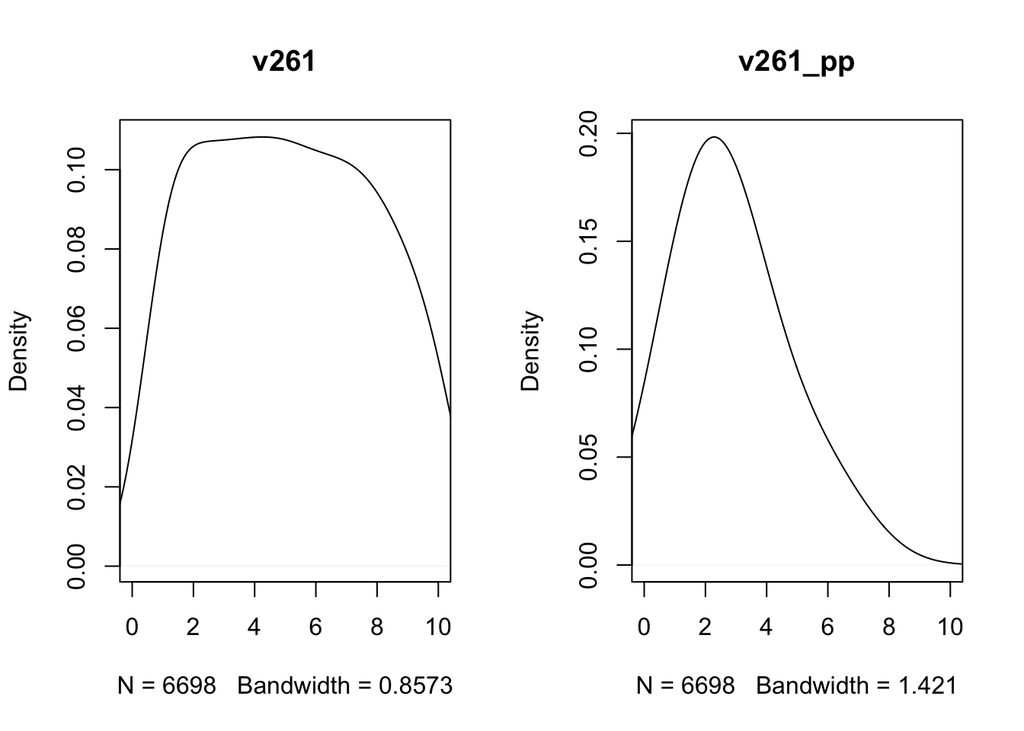

```r
par(mfrow=c(1,2))

plot(density(int.df$v261[int.df$v261 > 0], adjust = 2),
     main = "v261", xlim = c(0, 10))
plot(density(int.df$v261_ppp[int.df$v261_ppp > 0], adjust = 6),
     main = "v261_pp", xlim = c(0, 10))
```

### Size of town

v276 was initially part of these left out variables. However, it might be interesting. Considering it’s distribution, I will consider it as a categorical variable.

```r
# Freq table
table(int.df$v276)
```

```
##
##   -4    1    2    3    4    5
## 2404 1201 1370 1229  890  951
```

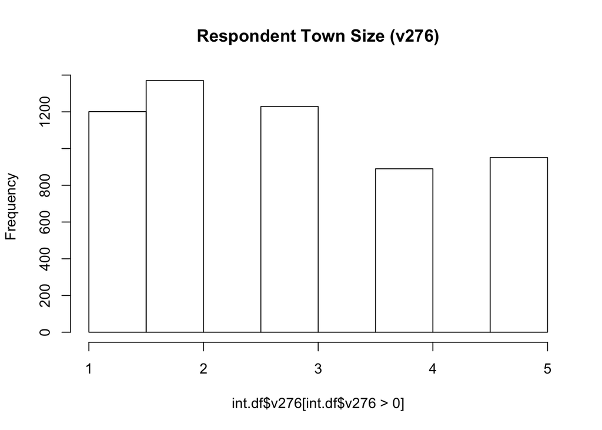

```r
# Distribution
hist(int.df$v276[int.df$v276 > 0], main = "Respondent Town Size (v276)")
```

In **conclusion** we can get rid of these variables for good

```r
# Forget about vairables of form v###
lostCol <- lostCol[!lostCol %in% var.number]
```

## Step 2

Now let’s look at the recoded versions of other variables (checking I’m keeping the one I want)

```r
# Look at var._r questions
var._r <- sapply(int.df[, grep("_r", lostCol, value = TRUE)], var_label)
data.frame(Var_Label = var._r)
```

```
##                                                                      Var_Label
## v228b_r           respondents country of birth (ISO 3166-1 numeric code) (Q66)
## v231b_r               fathers country of birth (ISO 3166-1 numeric code) (Q69)
## v233b_r               mothers country of birth (ISO 3166-1 numeric code) (Q69)
## v242_r  What age did you complete your education (recoded in intervals) (Q80)
## v243_r                             educational level respondent: recoded (Q81)
## v251b_r      spouse/partners country of birth (ISO 3166-1 numeric code) (Q88a)
## v252_r                         educational level spouse/partner: recoded (Q89)
## v261_r                         household total net income (Q98) (income level)
## v262_r                                 educational level father: recoded (Q99)
## v263_r                                educational level mother: recoded (Q100)
## v278c_r                          time of interview: start (constructed) (Q108)
## v279c_r                            time of interview: end (constructed) (Q108)
## v279d_r            time of interview: duration in minutes (constructed) (Q109)
## v281a_r                 language of interview (WVS/EVS numeric 3-digit) (Q110)
```

In **conclusion**, we can get rid of all of them

```r
# Forget about var._r columns
lostCol <- lostCol[!lostCol %in% names(var._r)]
```

## Step 3: looking at variables with letter right after number

```r
# Look at var.letter questions
var.letter <- sapply(int.df[,
                            grep("v[0-9]*[a-z]$", lostCol, value = TRUE)],
                     var_label)
data.frame(Var_Label = var.letter)
```

```
##                                                                  Var_Label
## v20a         do you belong to: I dont know (MQ: to complete question) (Q4)
## v20b           do you belong to: no answer (MQ: to complete question) (Q4)
## v30a       dont like as neighbours: wouldn't mind having any of these (Q6)
## v30b  dont like as neighbours: I dont know (MQ: to complete question) (Q6)
## v30c    dont like as neighbours: no answer (MQ: to complete question) (Q6)
## v45a                 important in a job: none of these (spontaneous) (Q11)
## v45b      important in a job: I dont know (MQ: to complete question) (Q11)
## v45c        important in a job: no answer (MQ: to complete question) (Q11)
## v96a  learn children at home: I dont know (MQ: to complete question) (Q28)
## v96b    learn children at home: no answer (MQ: to complete question) (Q28)
## v228b         respondents country of birth (ISO 3166-1/3 alpha code) (Q66)
## v231b             fathers country of birth (ISO 3166-1/3 Alpha code) (Q69)
## v233b             mothers country of birth (ISO 3166-1/3 Alpha code) (Q71)
## v239a                               number of children in household (Q77A)
## v239b                          number of children outside household (Q77B)
## v248a                          how many people do/did you supervise (Q86a)
## v251b    spouse/partners country of birth (ISO 3166-1/3 Alpha code) (Q88a)
## v278a                                 time of interview: start hour (Q108)
## v278b                               time of interview: start minute (Q108)
## v279a                                   time of interview: end hour (Q108)
## v279b                                 time of interview: end minute (Q108)
## v281a                  language of interview (ISO 639-1 Alpha code) (Q110)
```

These vairables belong to one of these groups:

- “dont know/no answer” to previous question - these are not in need to be kept as their value is already reported as a missing value in the previous questions (are they? check with one) <—- CHECK!!!
- country of birth - this info is already recorded in other variables I have actively kept.
- gated question - questions related to partners that are asked only to people that do have partners.
- time of interview - meta data that slipped through

In **conclusion**, we can get rid of all of them

```r
# Forget about var._r columns
lostCol <- lostCol[!lostCol %in% names(var.letter)]
```

## Step 4: looking at country specific variables

### cs like variables

Let’s start with vairables with the "_cs" tag in their name

```r
var._cs <- sapply(int.df[,
                         grep("_cs$", lostCol, value = TRUE)
                         ],
                  var_label)
data.frame(Var_Label = var._cs)
```

```
##                                                                                Var_Label
## v52_cs  which religious denomination do you belong to (Q13a) (ISO 3166-1, country-specif
## v174_cs   which political party appeals to you most (Q49) (ISO 3166-1, country-specific)
## v175_cs is there another party that appeals to you (Q49a) (ISO 3166-1, country-specific)
## v243_cs                 educational level respondent: country-specific, ISO 3166-1 (Q81)
## v252_cs             educational level spouse/partner: country-specific, ISO 3166-1 (Q89)
## v262_cs                     educational level father: country-specific, ISO 3166-1 (Q99)
## v263_cs                    educational level mother: country-specific, ISO 3166-1 (Q100)
```

```r
# Forget about var._cs$ columns
lostCol <- lostCol[!lostCol %in% names(var._cs)]
```

Next you can focus on more complex cs variables: the "_cs_DE" group.

```r
var._cs_ <- sapply(int.df[,
                         grep("_cs", lostCol, value = TRUE)
                         ],
                  var_label)
data.frame(Var_Label = var._cs_)
```

```
##                                                                           Var_Label
## v243_cs_DE1         DE COUNTRY-SPECIFIC: educational level respondent (Q81), SCHOOL
## v243_cs_DE2        DE COUNTRY-SPECIFIC: educational level respondent (Q81), STUDIES
## v243_cs_DE3     DE COUNTRY-SPECIFIC: educational level respondent (Q81), VOCATIONAL
## v252_cs_DE1     DE COUNTRY-SPECIFIC: educational level spouse/partner (Q89), SCHOOL
## v252_cs_DE2    DE COUNTRY-SPECIFIC: educational level spouse/partner (Q89), STUDIES
## v252_cs_DE3 DE COUNTRY-SPECIFIC: educational level spouse/partner (Q89), VOCATIONAL
## v262_cs_DE1             DE COUNTRY-SPECIFIC: educational level father (Q99), SCHOOL
## v262_cs_DE2            DE COUNTRY-SPECIFIC: educational level father (Q99), STUDIES
## v262_cs_DE3         DE COUNTRY-SPECIFIC: educational level father (Q99), VOCATIONAL
## v263_cs_DE1            DE COUNTRY-SPECIFIC: educational level mother (Q100), SCHOOL
## v263_cs_DE2           DE COUNTRY-SPECIFIC: educational level mother (Q100), STUDIES
## v263_cs_DE3        DE COUNTRY-SPECIFIC: educational level mother (Q100), VOCATIONAL
```

These variables are all education related and require a bit more investigation to make sure that we are recording the info in the other educational variables. As always, there are four educational vairables: respondent, father, mother, possible partner. Looking at the codebook it seems clear that the variables "v2**_cs_DE1" are measuring education based on the specifc german system, while "v2**_ISCED_1" are measuring the same info but standardized. You can check this:

```r
# Select just Germany observations
int.de <- int.df %>%
  filter(country == "Germany")

# Same number of observations (i.e. not a matrix specific question)
sapply(int.de[, c("v243_ISCED_1", "v243_cs_DE1", "v243_cs_DE2")],
       function(x) sum(table(x)))
```

```
## v243_ISCED_1  v243_cs_DE1  v243_cs_DE2
##         1494         1494         1494
```

As a result, I decide to exclude them as well.

```r
# Forget about var._cs$ columns
lostCol <- lostCol[!lostCol %in% names(var._cs_)]
```

### Other Germany Specific questions

```r
var._DE <- sapply(int.df[,
                        grep("[0-9]_DE", lostCol, value = TRUE)
                        ],
                 var_label)
data.frame(Var_Label = var._DE)
```

```
##                                                                               Var_Label
## v72_DE    DE MODIFIED (additional middle cat): child suffers with working mother (Q25A)
## v73_DE  DE MODIFIED (additional middle cat): women really want home and children (Q25B)
## v74_DE DE MODIFIED (additional middle cat): family life suffers when woman has full-tim
## v75_DE DE MODIFIED (additional middle cat): man's job is to earn money; woman's job is
## v76_DE DE MODIFIED (additional middle cat): men make better political leaders than wome
## v77_DE DE MODIFIED (additional middle cat): university education more important for a b
## v78_DE DE MODIFIED (additional middle cat): men make better business executives than wo
## v79_DE DE MODIFIED (additional middle cat): one of main goals in life has been to make
```

Once again, I need to check consistency of information between what is recorded in the non-DE specific variables for the German respondents. Let’s see:

```r
# Excluding the people that responded to the matrix desing, no one respondend
table(int.df[int.df$country == "Germany", "v72_DE"])
```

```
##
##   -4
## 1494
```

```r
# In the matrix desing people did answer to this question
table(mad.df[mad.df$country == "Germany", "v72_DE"])
```

```
##
##  -10   -9   -4   -2   -1    1    2    3    4    5
##    1 1623  688   33   32   82  333  305  577  288
```

The "_DE" quesitons were asked to the matrix design respondents. We are not considering those respondents, so I can forget about these questions.

```r
# Forget about var._cs$ columns
lostCol <- lostCol[!lostCol %in% names(var._DE)]
```

### N* regional codes

```r
var._N <- sapply(int.df[,
                        grep("_N[0-9]", lostCol, value = TRUE)
                        ],
                 var_label)
data.frame(Var_Label = var._N)
```

```
##                                                             Var_Label
## v275b_N2     region where interview was conducted: NUTS-2 code (Q105)
## v275b_N1     region where interview was conducted: NUTS-1 code (Q105)
## v275c_N2 region where interview was conducted: ISO_NUTS-2 code (Q105)
## v275c_N1 region where interview was conducted: ISO_NUTS-1 code (Q105)
```

This level of detail of where interview took place is not particularly interesting for the purpuses of this study. As variables covering this info I already have the country where the interview took place (for “cultural” reasoning) and the size of the town the respondent lives in (for urbanistic control). As a result, I decide to forget about them forever.

```r
# Forget about var._N$ columns
lostCol <- lostCol[!lostCol %in% names(var._N)]
```

### Italian Experimental Questions

```r
# Which vairables are we talking about
var._IT <- sapply(int.df[,
                        grep("_IT", lostCol, value = TRUE)
                        ],
                 var_label)
data.frame(Var_Label = var._IT)
```

```
##                                                                                Var_Label
## v24a_IT IT EXPERIMENT (item wording modified): dont like as neighbours: foreign workers
## v24b_IT IT EXPERIMENT (item wording modified): dont like as neighbours: immigrants (Q6C:
```

```r
# Proportion of respondends per category
round(prop.table(table(int.df$v24a_IT)), 3)
```

```
##
##    -4    -2    -1     1     2
## 0.960 0.001 0.002 0.003 0.034
```

Experimental questions are left out because we have too few respondents on them

```r
# Forget about var._IT$ columns
lostCol <- lostCol[!lostCol %in% names(var._IT)]
```

### Neterlands and other country specific questions "_11c"

```r
# Which vairables are we talking about
var._11c <- sapply(int.df[,
                        grep("_11c", lostCol, value = TRUE)
                        ],
                 var_label)
data.frame(Var_Label = var._11c)
```

```
##                                                                                 Var_Label
## v133_11c MODIFIED (cat. 0 displayed): democracy: governments tax the rich and subsidize t
## v134_11c MODIFIED (cat. 0 displayed): democracy: religious authorities interpret the laws
## v135_11c MODIFIED (cat. 0 displayed): democracy: people choose their leaders in free elec
## v136_11c MODIFIED (cat. 0 displayed): democracy: people receive state aid for unemploymen
## v137_11c MODIFIED (cat. 0 displayed): democracy: the army takes over when government is i
## v138_11c MODIFIED (cat. 0 displayed): democracy: civil rights protect people from state o
## v139_11c MODIFIED (cat. 0 displayed): democracy: the state makes people’s incomes equal (
## v140_11c          MODIFIED (cat. 0 displayed): democracy: people obey their rulers (Q39H)
## v141_11c MODIFIED (cat. 0 displayed): democracy: women have the same rights as men (Q39I)
```

Again, we need to check how many respondents were given these questions. For this specific question, 4 countries were considered: Denmark, Finalnd, Iceland, and the Netherlands. We only have this latter country in our dataset. Let’s focus on it.

```r
# Select just Netherlands observations
int.nl <- int.df %>%
  filter(country == "Netherlands")
```

Notice how, 1718 observations were not given the standard version for these questions.

```r
sapply(int.df[int.df$country == "Netherlands", paste0("v", 133:141)],
       function(x) table(x))
```

```
##    v133 v134 v135 v136 v137 v138 v139 v140 v141
## -4 1718 1718 1718 1718 1718 1718 1718 1718 1718
## -2    3    3    2    2    3    2    2    2    3
## -1   31   40   29   28   33   33   29   29   23
## 0     2    3    1    2    7    1    2    3    4
## 1    51  298   13   19  228   23   94  133   12
## 2    13  109    6    6  104   13   69   83    4
## 3    37   68    4   14   74    9   82   61    2
## 4    34   42    4   11   49    9   57   80    4
## 5    57   36   21   46   53   25   74   81    8
## 6    67   29   23   54   35   39   76   77   10
## 7   133   24   47  125   31   82   76   51   28
## 8   178   16  136  196   41  159   66   46   77
## 9    29    3  109   68    8   97   28   18  110
## 10   51   15  291  115   20  194   31   22  401
```

Which are the 1718 onservations to which questions "_11c" are given.

```r
sapply(int.nl[, names(var._11c)],
       function(x) {
        temp <- data.frame(table(x[x > -4]))[,2]
        names(temp) <- data.frame(table(x[x > -4]))[,1]
        c( temp, tot = sum(temp) )
       }
       )
```

```
##     v133_11c v134_11c v135_11c v136_11c v137_11c v138_11c v139_11c v140_11c
## -2        17       13       14       21       19       19       16       16
## -1       213      251      151      134      220      171      173      177
## 0         68      383       12        8      430       23       69      210
## 1         98      426       10       67      334       24      267      344
## 2         51      148        7       39      121        7      127      154
## 3         82      115        7       62      110        6      155      147
## 4         68       51       11       58       65       21      124      109
## 5        101       61       31       71       65       34      106       94
## 6        223      120       82      182      115       95      199      172
## 7        201       54       84      240      103      123      172      124
## 8        292       42      154      321       69      251      131      104
## 9        121       18      189      202       26      258       74       31
## 10       183       36      966      313       41      686      105       36
## tot     1718     1718     1718     1718     1718     1718     1718     1718
##     v141_11c
## -2        14
## -1        90
## 0          6
## 1         28
## 2          7
## 3          5
## 4         15
## 5         19
## 6         64
## 7         50
## 8        131
## 9        184
## 10      1105
## tot     1718
```

Now, for the purpuses of this study, it is completly fine to mix the answers of the two quesitons: I want respondents in the Netherlands to have just one variable for this set.

```r
int.nl.fix <- int.df

var_nams <- paste0("v", 133:141)
cnt_indx <- int.nl.fix$country == "Netherlands" # rows from NL

for (v in var_nams) {
  var_indx <- int.nl.fix[, v] == -4 # rows did not recieve Q

  toFill <- int.df[cnt_indx & var_indx, paste0(v, "_11c")]

  int.nl.fix[cnt_indx & var_indx, v] <- toFill
}
```

And we can check that it worked for one sample variable:

```r
v <- var_nams[1] # choose sample variable
var_indx <- int.df[, v] == -4 # rows did not recieve Q

# Asked version 2, keeps version 2 as response
cbind(
  int.df[cnt_indx & var_indx, c(v, paste0(v, "_11c"))],
  int.nl.fix[cnt_indx & var_indx, v]
)[1:5, ]
```

```
##      v133 v133_11c int.nl.fix[cnt_indx & var_indx, v]
## 6328   -4       10                                 10
## 6329   -4       -1                                 -1
## 6330   -4       10                                 10
## 6331   -4        9                                  9
## 6332   -4        6                                  6
```

```r
# Asked version 1, keeps version 1 as response
cbind(
  int.df[cnt_indx & !var_indx, c(v, paste0(v, "_11c"))],
  int.nl.fix[cnt_indx & !var_indx, v]
)[1:5, ]
```

```
##      v133 v133_11c int.nl.fix[cnt_indx & !var_indx, v]
## 5642    1       -4                                   1
## 5643    1       -4                                   1
## 5644   10       -4                                  10
## 5645    8       -4                                   8
## 5646   10       -4                                  10
```

After this is done, I can get rid of this country specific questions:

```r
# Forget about var._11c columns
lostCol <- lostCol[!lostCol %in% names(var._11c)]
```

### Post-materialism costructed variable (v111_4)

v111_4 is a combination of variable v110 and v111 that measures postmaterialism. I do not particularly care about this construct in my substantive models, so I will keep the original vairables as separated.

```r
# Forget about v111_4 column
lostCol <- lostCol[!lostCol %in% "v111_4"]
```

And now the object lostCol is empty: I have checked all the variables that I had originally excluded to confirm their exclusion.